# STA-290 HW 2

2024-02-05

## Question 1

This question is Question 4.2 from the textbook and has been reproduced here. The dataset below contains the results from a poll based on a random sample with two variables: `response`, indicating their response to the poll question, and `political`, reporting their self-reported political ideology.

Nine-hundred and ten (910) randomly sampled registered voters from Tampa, FL were asked if they thought workers who have illegally entered the US should be (i) allowed to keep their jobs and apply for US citizenship, (ii) allowed to keep their jobs as temporary guest workers but not allowed to apply for US citizenship, or (iii) lose their jobs and have to leave the country.

```r
## Copy and run this code to create table
immigration <- read.csv("https://collinn.github.io/data/immigrationpoll.csv")
```

*Use the appropriate tables to answer the following questions:*

1. What percent of these Tampa, FL voters identify themselves as conservatives?
2. What percent of these Tampa, FL voters are in favor of the citizenship option?
3. What percent of these Tampa, FL voters identify themselves as conservatives and are in favor of the citizenship option?
4. What percent of these Tampa, FL voters who identify themselves as conservatives are in favor of the citizenship option? What percent of moderates share this view? What percent of liberals share this view?
5. Do political ideology and views on immigration appear to be associated? Explain your reasoning.

## Question 2

This question uses the `tips` dataset. Recall that the variables are:

- `total_bill` Total amount spent on meal
- `tip` total tip
- `sex` sex of the individual paying the bill
- `smoker` indicator of whether or not the bill payer was a smoker
- `day` Day of the week of the meal
- `time` Time of day
- `size` Number of people in the party

```r
tips <- read.csv("https://collinn.github.io/data/tips.csv")
```

**Part A** Using the `tips` dataset, determine which day was the least popular for diners to visit. Which day was the *most popular* for having lunch?

**Part B** Given that a particular meal was “Dinner”, what is the *probability* that the person paying the bill was a male?

**Part C** Give the odds ratio comparing the odds of a *female being a smoker* compared to the odds of a *male being a smoker* (Hint: what value is considered an “event”?). Do sex and smoking status appear to be associated?

**Part D** Create the table with margin sums that best captures the information in the following plot. Be mindful of which should be the row and which should be the column.

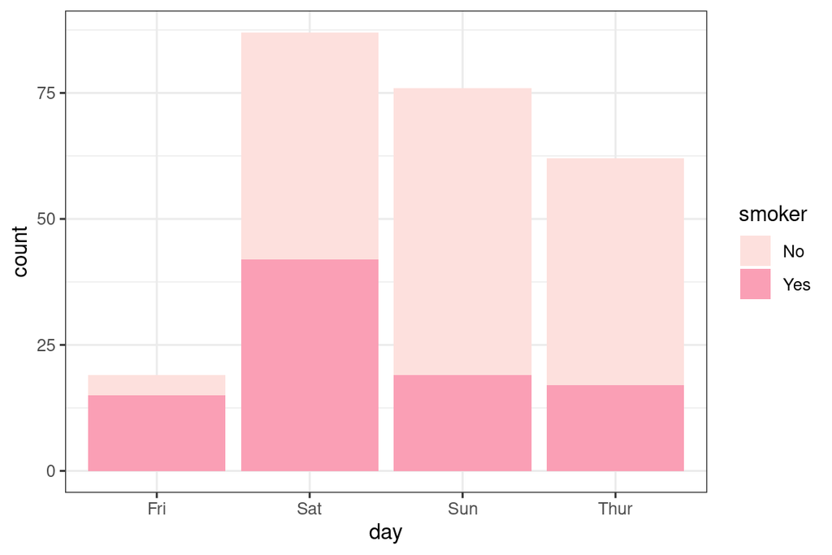

| Smoker | Time Dinner | Time Lunch |
| --- | --- | --- |
| No | 0.602 | 0.662 |
| Yes | 0.398 | 0.338 |

## Question 3

The table and plots below present the results of a social survey relating individuals’ income levels with their reported sense of happiness.

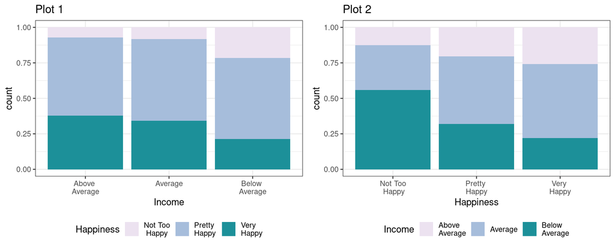

| Income Level | Happiness Not Too Happy | Happiness Pretty Happy | Happiness Very Happy | Total Sum |
| --- | --- | --- | --- | --- |
| Above Average | 21 | 159 | 110 | 290 |
| Average | 53 | 372 | 221 | 646 |
| Below Average | 94 | 249 | 93 | 436 |

**Part A:** Of all of the individuals who have a below average income, what proportion of them report being “Pretty Happy”?

**Part B** Would **Plot 1** or **Plot 2** be more useful in answering the question: “Which income group has the highest proportion of individuals who consider themselves ‘Not too Happy’?” Justify your answer.

**Part C:** For Part C, we are interested in answering the question, “*Is having an above average income associated with being ‘very happy’?*”